# Milestone 6- TRI Group

Author

Sonam Kaur, Shayah LaCour, Ashley Lee, & Angela Qian

# Deliverable 1 - Dashboard Link

Google Looker: https://lookerstudio.google.com/reporting/188aeaa7-7012-4025-963c-1cae65f9887b

# Deliverable 2 - Dashboard Requirements Checklist

[figure not shown]

View link for more

# Deliverable 3 - Screenshot Tour

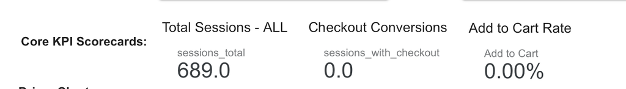

- what each section answers: The core KPI scorecards answer whether or not we are improving across all objectives for conversions and improving performance overall.
- how stakeholders should use it: This allows the team to check in on whether things are progressing or the campaign is yielding the right returns.
- which metrics are “north star” vs diagnostics: These three are definitely north star metrics.

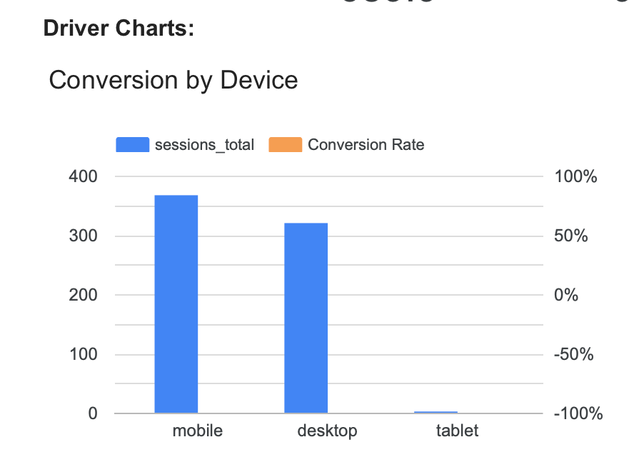

- what each section answers: This chart shows total sessions and conversion rate split by device category.
- how stakeholders should use it: We can use these results to identify where our key drivers of growth are accessing our content, which can alter campaign strategy or UX.
- which metrics are “north star” vs diagnostics: The conversion rate is the north star here rather than the sessions (diagnostic). We want to see which device drives people to convert.

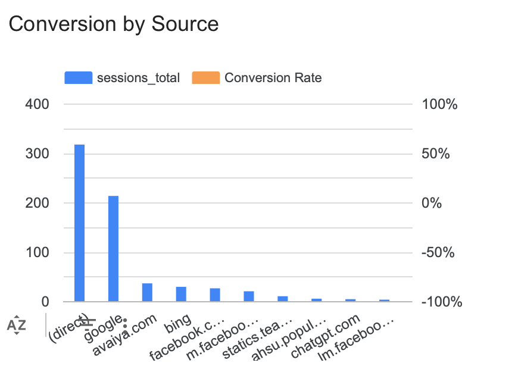

- what each section answers: This is sessions and conversion rate by source, so whether that is direct search, affiliated search or ads.
- how stakeholders should use it: It allows us to prioritize which source is performing well, and adjust ad campaigns placement accordingly.
- which metrics are “north star” vs diagnostics: Both sessions and conversion rate are north star metrics.